# (Loan Data from Prosper)

## Investigation Overview

> For the presentation, I focus on the variables numeric and categorical affecting "Loan Original Amount" and "Borrower Rate" throuhg many plots like (Scatter, Box, Violin, Reegplots & Heatmaps)

## Dataset Overview

We will deal with a variety of variables like ..

> 1- LoanOriginalAmount --> The origination amount of the loan.

> 2- MonthlyLoanPayment --> The scheduled monthly loan payment.

> 3- Term --> The length of the loan expressed in months.

> 4- BorrowerRate --> The Borrower's interest rate for this loan.

> 5- ListingCategory (numeric) --> The category of the listing that the borrower selected when posting their listing: 0 - Not Available, 1 - Debt Consolidation, 2 - Home Improvement, 3 - Business, 4 - Personal Loan, 5 - Student Use, 6 - Auto, 7- Other, 8 - Baby&Adoption, 9 - Boat, 10 - Cosmetic Procedure, 11 - Engagement Ring, 12 - Green Loans, 13 - Household Expenses, 14 - Large Purchases, 15 - Medical/Dental, 16 - Motorcycle, 17 - RV, 18 - Taxes, 19 - Vacation, 20 - Wedding Loans

> 6- Occupation --> The Occupation selected by the Borrower at the time they created the listing.

> 7- EmploymentStatus --> The employment status of the borrower at the time they posted the listing.

> 8- EmploymentStatusDuration --> The length in months of the employment status at the time the listing was created.

> 9- IsBorrowerHomeowner --> A Borrower will be classified as a homowner if they have a mortgage on their credit profile or provide documentation confirming they are a homeowner.

> 10- IncomeVerifiable --> The borrower indicated they have the required documentation to support their income.

> 11- StatedMonthlyIncome --> The monthly income the borrower stated at the time the listing was created.

> 12- TotalProsperLoans --> Number of Prosper loans the borrower at the time they created this listing. This value will be null if the borrower had no prior loans.

> 13- Recommendations --> Number of recommendations the borrower had at the time the listing was created.

## (Visualization 1)

## Stated Monthly Income vs Loan Original Amount

> In general lower incomes tend to have lower loans, and as the income incraeses the Loan Original Amount variety of values and values themselves increases to.

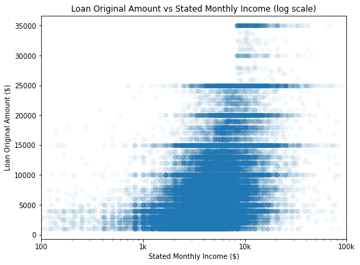

```python
plt.figure(figsize = [8, 6])
plt.scatter(data = dfx, x = 'StatedMonthlyIncome', y = 'LoanOriginalAmount', alpha = 1/30)
plt.xscale('log')
plt.xlim((100,100000))
plt.xticks([100, 1000, 10000, 100000], [100, '1k', '10k', '100k'])
plt.title('Loan Original Amount vs Stated Monthly Income (log scale)')
plt.xlabel('Stated Monthly Income ($)')
plt.ylabel('Loan Original Amount ($)')
plt.show();
```

## (Visualization 2)

## Loan Original Amount AND Borrower Rate

## vs ...

## Employment Status AND Is Borrower Home Owner AND Income Verifiable

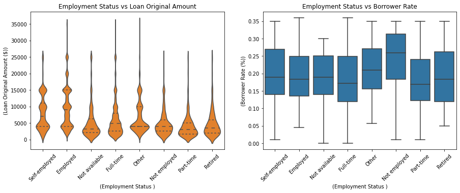

```python
violinBox('EmploymentStatus', 'Employment Status', '')
```

> b- The **Home Owner Borrowers** have higher Loan Original Amount on average, AND lower Borrow Rate on averager THAN Non Home Owner.

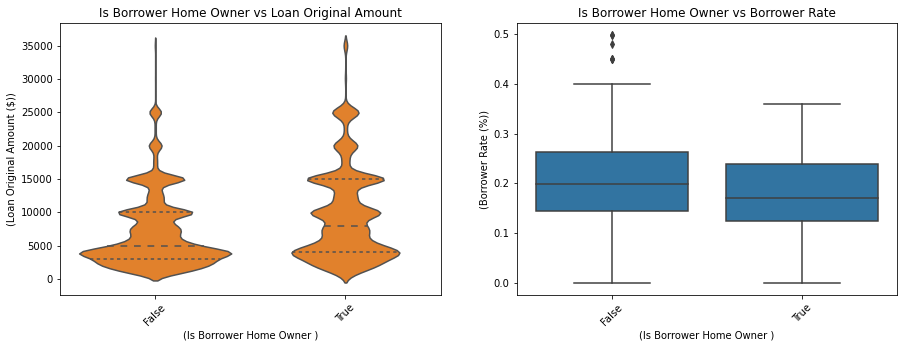

```python
violinBox('IsBorrowerHomeowner', 'Is Borrower Home Owner', '')
```

> c- The **True Income Verifiable** have higher Loan Original Amount on average, AND lower Borrow Rate on averager THAN False Income Verifiable.

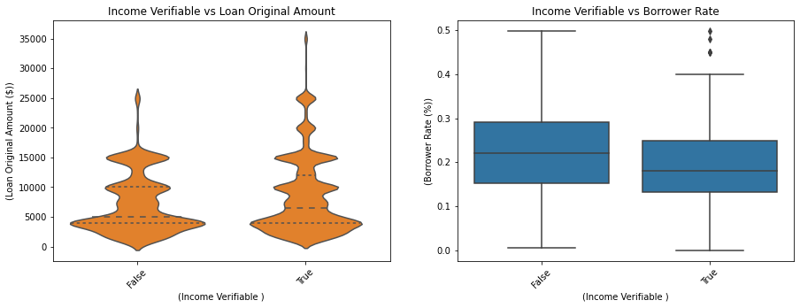

```python
violinBox('IncomeVerifiable', 'Income Verifiable', '')
```

## (Visualization 3)

## Stated Monthly Income vs Loan Original Amount vs ..

## Borrower Rate AND Term

> Over the positive relationship between Stated Monthly Income AND Loan Original Amount, as the both increase --> we can observe **decreasing in Borrower Rate** AND **increasing in the Term**

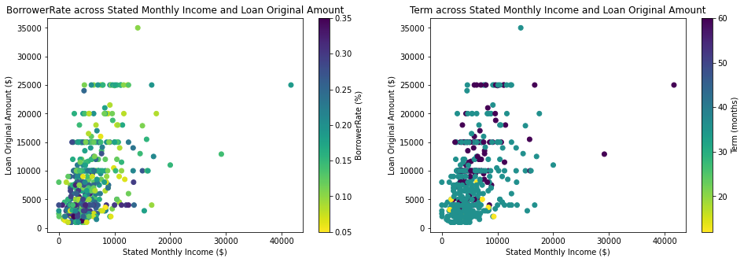

```python
varList, barList = ['BorrowerRate', 'Term'], ['(%)', '(months)']
plt.figure(figsize = [16, 5])
count = 0
for var in varList:
    plt.subplot(1, 2, count+1)
    plt.scatter(data = dfxSub, x = 'StatedMonthlyIncome', y = 'LoanOriginalAmount', c = var, cmap = 'viridis_r');
    plt.colorbar(label = f'{var} {barList[count]}');
    plt.xlabel('Stated Monthly Income ($)');
    plt.ylabel('Loan Original Amount ($)');
    plt.title(f'{var} across Stated Monthly Income and Loan Original Amount')
    count += 1
```

## (Visualization 4)

## Employment Status vs Loan Listing Category vs Loan Original Amount

> Higher LoanOriginalAmount on Average can be observed along some Employment Status like **Employed, Self_employed, Full-Time** and along some Listing Category like **Debt Consolidation, Home Improvement, Business, Large Purchases, Medical/Dental, Wedding Loans**

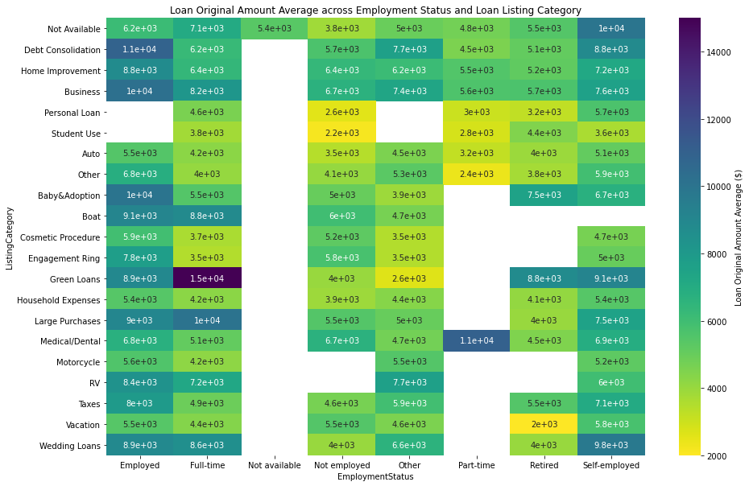

```python
threeVarHeatmap()
```